# Data Overview

#### When we compare these factors that appear meaningful by country, what key insights are revealed?

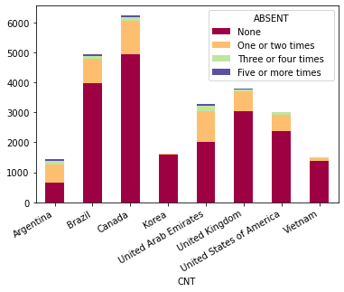

```python
#Next, lets explore the data by country, both raw counts and proportions.

#set categories, then define function by category type
cat_type1 = ['None  ', 'One or two times  ', 'Three or four times  ', 'Five or more times  ']
cat_type2 = ['None', 'One', 'Two', 'Three or more']
cat_type3 = ['Strongly agree', 'Agree', 'Disagree', 'Strongly disagree']
cat_type4 = ['0-10 books ', '11-25 books ', '26-100 books ', '101-200 books ', '201-500 books ', 'More than 500 books']
cat_type5 = ['Never or rarely', 'Sometimes', 'Often', 'Always or almost always']
cat_type6 = ['Not at all like me','Not much like me', 'Somewhat like me', 'Mostly like me', 'Very much like me']
cat_type7 = ['No', 'Yes']

def propbar(A,B):
    cat2_order = B #category type
    artists = [] # for storing references to plot elements
    baselines = np.zeros(len(labels))
    cat1_counts = df_clean['CNT'].value_counts()

    # for each second-variable category:
    for i in range(len(cat2_order)):
        # isolate the counts of the first category,
        cat2 = cat2_order[i]
        inner_counts = df_clean[df_clean[A] == cat2]['CNT'].value_counts()
        inner_props = inner_counts / cat1_counts
        # then plot those counts on top of the accumulated baseline
        bars = plt.bar(x = np.arange(len(labels)),
                       height = inner_props[labels],
                       bottom = baselines)
        artists.append(bars)
        baselines += inner_props[labels]

        plt.xticks(np.arange(len(labels)), labels)
        plt.legend(reversed(artists), reversed(cat2_order), framealpha = 1,
                   bbox_to_anchor = (1, 0.5), loc = 6)
        plt.xticks(rotation=45, ha='right');

#raw count bar graph defined
def bibar(A):
    ax=df_clean.groupby(["CNT", A]).size().unstack().plot(cmap="Spectral", kind='bar', stacked=True)
    plt.xticks(rotation=30, ha='right');

bibar("ABSENT")
```

The stacked bar shows us the highest participation from Brazil and Canada. While visually interesting, the stacked bar is a hard to draw comparisons.

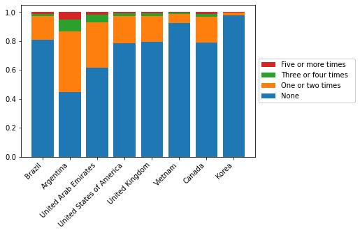

```python
propbar("ABSENT", cat_type1)
```

We continue to see that most assessed students had fewer than two absences. Argentina reports the highest number of absences.

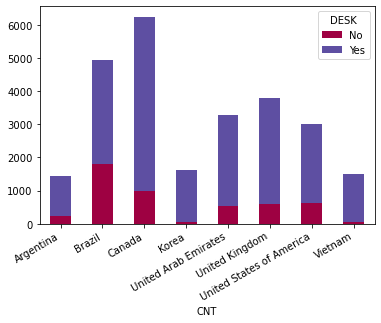

```python
bibar("DESK")
```

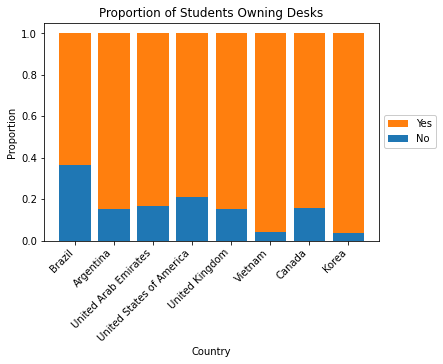

```python
propbar("DESK", cat_type7)
plt.title('Proportion of Students Owning Desks')
plt.xlabel('Country')
plt.ylabel('Proportion');
```

Korean students (who have highest PV) almost all have desks. Brazilians (who fared worst) have the most students without desks.

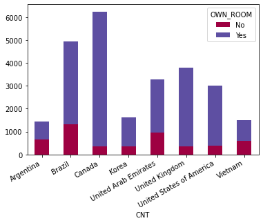

```python
bibar("OWN_ROOM")
```

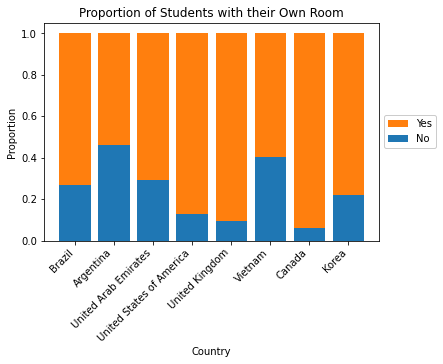

```python
propbar("OWN_ROOM", cat_type7)
plt.title('Proportion of Students with their Own Room')
plt.xlabel('Country')
plt.ylabel('Proportion');
```

English-speaking nations in our subset have higher proportions of students with their own rooms.

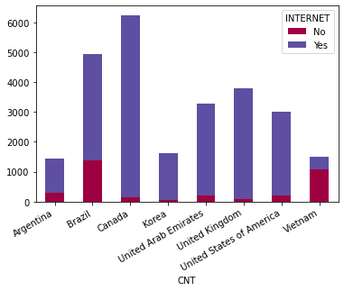

```python
bibar("INTERNET")
```

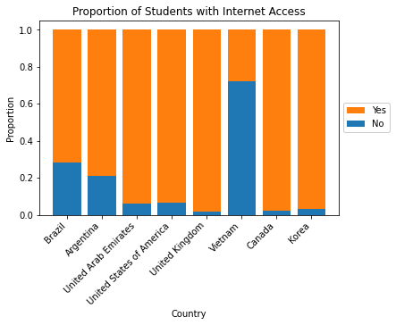

```python
propbar("INTERNET", cat_type7)
plt.title('Proportion of Students with Internet Access')
plt.xlabel('Country')
plt.ylabel('Proportion');
```

Wow, most Vietnamese students do not have internet access, yet they are nearer the top with outcomes.

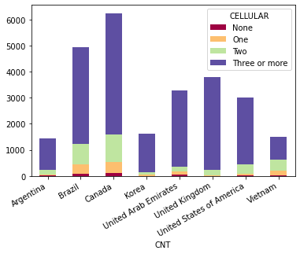

```python
bibar("CELLULAR")
```

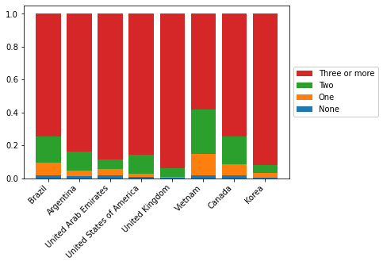

```python
propbar('CELLULAR', cat_type2)
```

Cell phones are fairly ubiquitous. We seee very low reports of none in all observed nations.

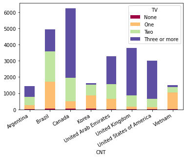

```python
bibar("TV")
```

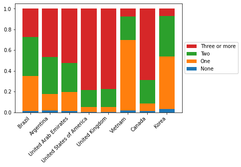

```python
propbar("TV", cat_type2)
```

TVs are also fairly ubiquitous. There are very low proportions of students reporting none.

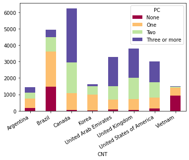

```python
bibar("PC")
```

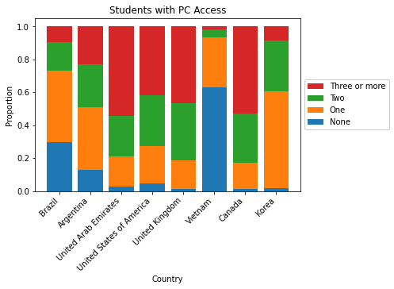

```python
propbar("PC", cat_type2)
plt.title('Students with PC Access')
plt.xlabel('Country')
plt.ylabel('Proportion');
```

While many Brazilian students have less access to computers, Vietnamese students have even less, yet scored better.

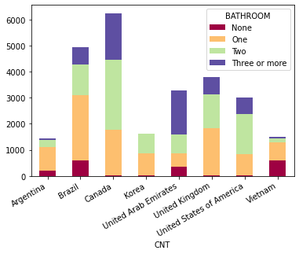

```python
bibar("BATHROOM")
```

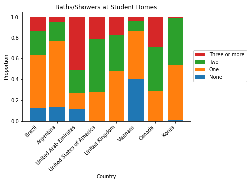

```python
propbar('BATHROOM', cat_type2)
plt.title('Baths/Showers at Student Homes')
plt.xlabel('Country')
plt.ylabel('Proportion');
```

Again, Vietnamese students appear to be the least resourced.

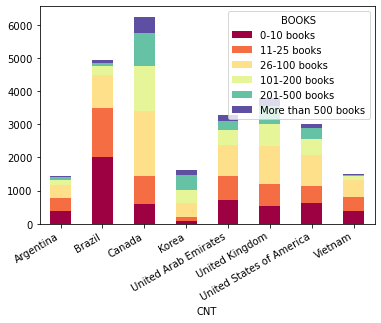

```python
bibar("BOOKS")
```

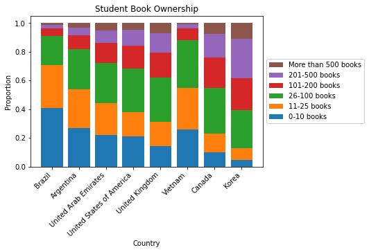

```python
propbar("BOOKS", cat_type4)
plt.title('Student Book Ownership')
plt.xlabel('Country')
plt.ylabel('Proportion');
```

After univariate and bivariate exploration of the data, what stands out to me for further exploration is the wide differences in access to resources. Let's study more specifically how this access is reflected in outcomes with mulivariate plotting.

```python
df_clean['MEAN_PVMATH'].describe() #determine values for placing scores in a level category
```

```
count    25833.000000
mean       474.565789
std         95.990174
min        178.851840
25%        402.874280
50%        471.342900
75%        541.447280
max        821.163740
Name: MEAN_PVMATH, dtype: float64
```

```python
#create copy of dataframe with new categorical column for PV levels
df1 = df_clean.copy()
df1['PV_LEVEL'] = 'AVG'
df1.loc[df1['MEAN_PVMATH'] <= 402.874280,'PV_LEVEL'] = 'LO'
df1.loc[df1['MEAN_PVMATH'] >= 541.447280,'PV_LEVEL'] = 'HI'
```

```python
cat_type7 = ['HI','AVG', 'LO']
level =  pd.api.types.CategoricalDtype(ordered=True, categories=cat_type7)
df1["PV_LEVEL"] = df1["PV_LEVEL"].astype(level)
```

```python
df1.info()
```

```
<class 'pandas.core.frame.DataFrame'>
Int64Index: 25833 entries, 4743 to 485487
Data columns (total 25 columns):
 #   Column                  Non-Null Count  Dtype
---  ------                  --------------  -----
 0   CNT                     25833 non-null  object
 1   SEX                     25833 non-null  object
 2   TARDY                   25833 non-null  category
 3   ABSENT                  25833 non-null  category
 4   SKIPPED                 25833 non-null  float64
 5   DESK                    25833 non-null  object
 6   OWN_ROOM                25833 non-null  object
 7   INTERNET                25833 non-null  object
 8   CELLULAR                25833 non-null  category
 9   TV                      25833 non-null  category
```

[output cut: 17 more lines]

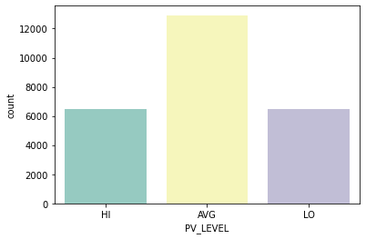

```python
sb.countplot(x="PV_LEVEL", data=df1, palette="Set3")
```

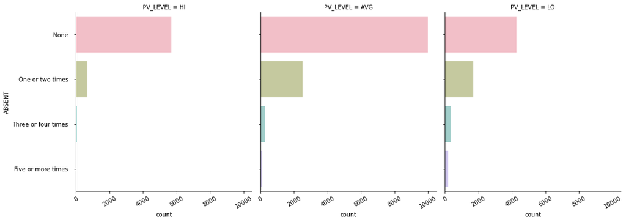

```python
def multiplot1(A):#variable A
    g=sb.catplot(y=A, col="PV_LEVEL", col_wrap=3, palette="husl", data=df1, kind="count", alpha=0.5)
    g.set_xticklabels(rotation=30);

multiplot1("ABSENT") #compare scores by attendance
```

Okay, again proportions seem like they'll provide more insight than raw counts.

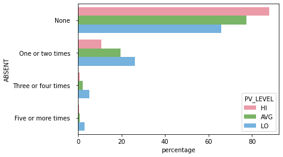

```python
cat_type1 = ['None  ', 'One or two times  ', 'Three or four times  ', 'Five or more times  ']
cat_type2 = ['None', 'One', 'Two', 'Three or more']
cat_type3 = ['Strongly agree', 'Agree', 'Disagree', 'Strongly disagree']
cat_type4 = ['0-10 books ', '11-25 books ', '26-100 books ', '101-200 books ', '201-500 books ', 'More than 500 books']
cat_type5 = ['Never or rarely', 'Sometimes', 'Often', 'Always or almost always']
cat_type6 = ['Not at all like me','Not much like me', 'Somewhat like me', 'Mostly like me', 'Very much like me']
cat_type7 = ['No', 'Yes']

def multipropplot(A,B): #variable A, category type B
    PVLEVEL_counts = (df1.groupby(['PV_LEVEL'])[A]
                                           .value_counts(normalize=True)
                                           .rename('percentage')
                                           .mul(100)
                                           .reset_index()
                                           .sort_values(A))
    category =  pd.api.types.CategoricalDtype(ordered=True, categories=B)
    PVLEVEL_counts[A] = PVLEVEL_counts[A].astype(category)
    p = sb.barplot(x="percentage", y=A, hue='PV_LEVEL', palette="husl", data=PVLEVEL_counts, alpha=0.8)


multipropplot("ABSENT", cat_type1)
```

Most students have no absences, but HI scoring proportionately more than others.

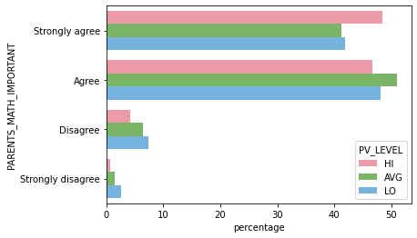

```python
multipropplot("PARENTS_MATH_IMPORTANT", cat_type3) #compare scores by perception of parental attitude
```

Most students agree or strongly agree that their parent believe math is important, slighlty higher proportion of HI scoring students.

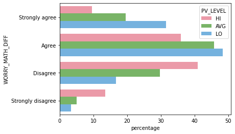

```python
multipropplot("WORRY_MATH_DIFF", cat_type3) #scores by worry that math will be difficult
```

Interesting, most students don't feel strongly about their worry that math will be difficult, though a significant amount more HI scoring students strongly disagree.

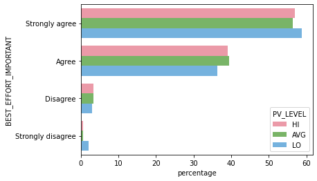

```python
multipropplot("BEST_EFFORT_IMPORTANT", cat_type3) #scores by belief in importance of best effort
```

The importance of best effort seems to have little/no effect on score.

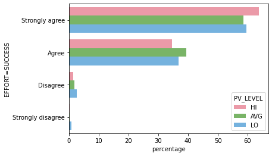

```python
multipropplot("EFFORT=SUCCESS", cat_type3) #scores by belief that success can be achieved with enough effort
```

The belief that effort will result in success seems to have little/no effect on score.

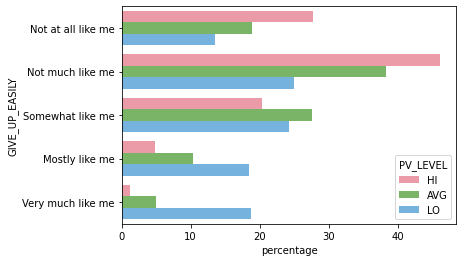

```python
multipropplot("GIVE_UP_EASILY", cat_type6) #compare scores by perserverance
```

Lo scoring students are much more evenly distributed amongst the answers, whereas HI scoring seem to more strongly identify with not giving up easily.

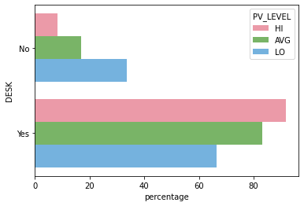

```python
multipropplot("DESK", cat_type7)
```

Many more LO scoring students are more likely to not have a desk

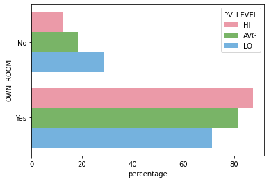

```python
multipropplot("OWN_ROOM", cat_type7)
```

Many more LO scoring students are more likely to not have their own room

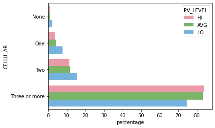

```python
multipropplot("CELLULAR", cat_type2)
```

Most students' families have cellular phones, but those with none are more likely to be LO scoring

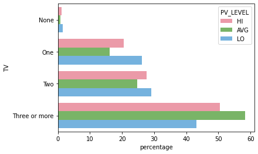

```python
multipropplot("TV", cat_type2)
```

TVs don't seem very significant in relation to score

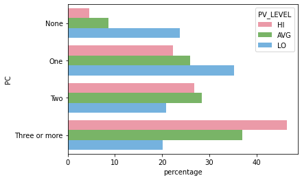

```python
multipropplot("PC", cat_type2)
```

PC ownership is more evenly distributed amongst LO scoring students, while HI scoring are more likely to have more

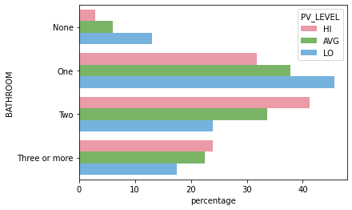

```python
multipropplot("BATHROOM", cat_type2)
```

Baths/Showers seem to have little relevance to score, though none to one is more correllated with LO scores.

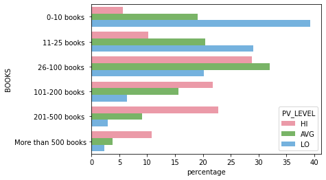

```python
multipropplot("BOOKS", cat_type4)
```

Family book ownership is pretty well distributed for HI scoring, with most having between 26-100 books, while LO scoring is much more skewed toward fewer books.

#### Brazil and Vietnam stand out as similarly under-resourced. Why is the distribution of their plausible values so different?

#### Once we focus on the lesser resourced nations in our subset: Brazil and Vietnam, what trends do we notice?

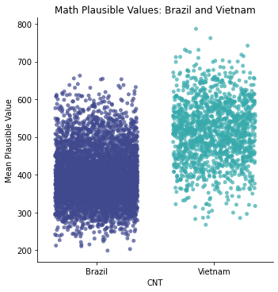

```python
#create dataframe
df1_BRVT = df1[df1['CNT'].isin(['Brazil', 'Vietnam'])]
#visualize score distribution
p=sb.catplot(x='CNT', y="MEAN_PVMATH", palette="mako", data=df1_BRVT, jitter=0.35, alpha=0.7)
p.set(title='Math Plausible Values: Brazil and Vietnam')
p.set(ylabel="Mean Plausible Value");
```

Brazilian PVs thin out right in the middle of Vietnam's PVs.

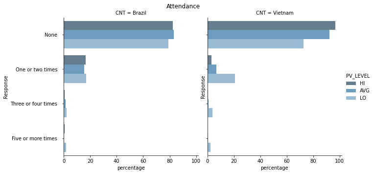

```python
#define categories and plotting
cat_type1 = ['None  ', 'One or two times  ', 'Three or four times  ', 'Five or more times  ']
cat_type2 = ['None', 'One', 'Two', 'Three or more']
cat_type3 = ['Strongly agree', 'Agree', 'Disagree', 'Strongly disagree']
cat_type4 = ['0-10 books ', '11-25 books ', '26-100 books ', '101-200 books ', '201-500 books ', 'More than 500 books']
cat_type5 = ['Never or rarely', 'Sometimes', 'Often', 'Always or almost always']
cat_type6 = ['Not at all like me','Not much like me', 'Somewhat like me', 'Mostly like me', 'Very much like me']

def multipropplot_BRVT(A,B,C): #variable, categorical type, title
    PVLEVEL_counts = (df1_BRVT.groupby(['CNT', 'PV_LEVEL'])[A]
                                           .value_counts(normalize=True)
                                           .rename('percentage')
                                           .mul(100)
                                           .reset_index()
                                           .sort_values(A))
    category =  pd.api.types.CategoricalDtype(ordered=True, categories=B)
    PVLEVEL_counts[A] = PVLEVEL_counts[A].astype(category)
    p = sb.catplot(x="percentage", y=A, hue='PV_LEVEL', col='CNT', palette="Blues_d", data=PVLEVEL_counts.sort_values('CNT'), kind="bar", alpha=0.8)
    p.set(ylabel="Response")
    plt.subplots_adjust(top=0.9)
    p.fig.suptitle(C)

multipropplot_BRVT("ABSENT", cat_type1, "Attendance")
```

We confirm again that the mojority of students have fewer than three absences.

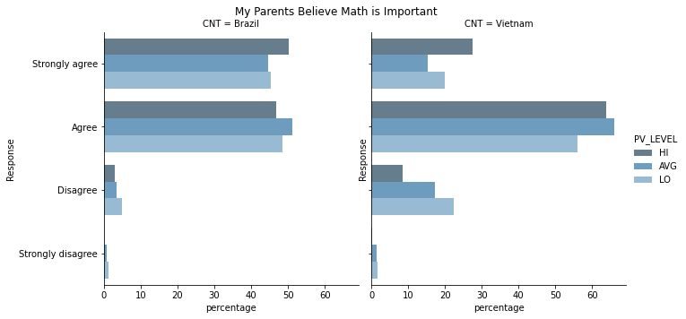

```python
multipropplot_BRVT("PARENTS_MATH_IMPORTANT", cat_type3, "My Parents Believe Math is Important") #compare scores by perception of parental attitude
```

Higher proportions of Vietnamese students think their parents don't beleive math is important, but it does skew toward the LO scoring.

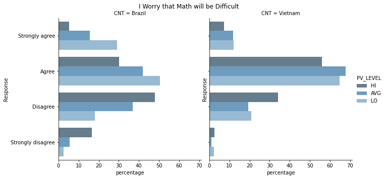

```python
multipropplot_BRVT("WORRY_MATH_DIFF", cat_type3, "I Worry that Math will be Difficult"); #scores by worry that math will be difficult
```

A slightly higher proportion of HI scoring Brazilian students strongly disagree with the statement "I worry that math will be difficult".

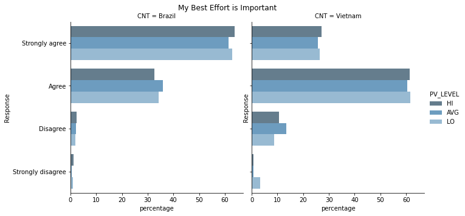

```python
multipropplot_BRVT("BEST_EFFORT_IMPORTANT", cat_type3, "My Best Effort is Important"); #scores by belief in importance of best effort
```

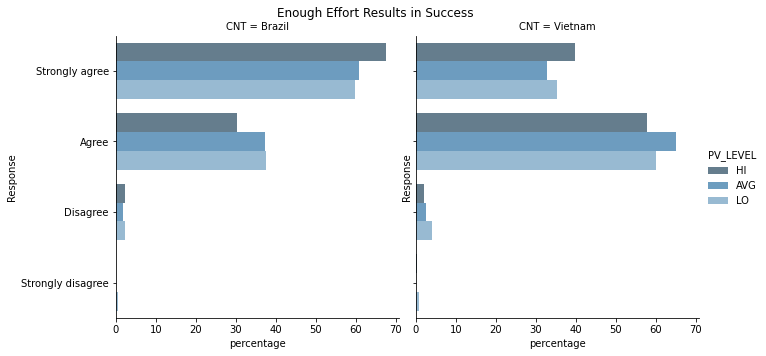

```python
multipropplot_BRVT("EFFORT=SUCCESS", cat_type3, "Enough Effort Results in Success"); #scores by belief that success can be achieved with enough effort
```

Almost none of Brazilian students strongly disagree that enough effort results in success and that their best effort is important.

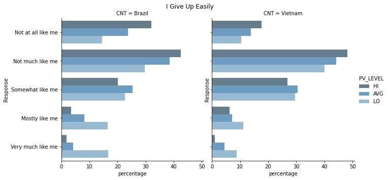

```python
multipropplot_BRVT("GIVE_UP_EASILY", cat_type6, "I Give Up Easily") #compare scores by perserverance
```

Both countries have similar distributions regarding perseverance but it appears more meaninfgul among the PV levels for Brazilian students.

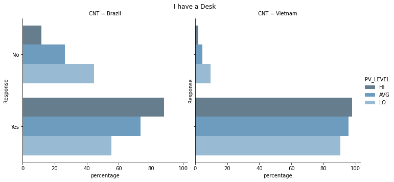

```python
multipropplot_BRVT("DESK", cat_type7, "I have a Desk");
```

While a greater proporiton of Vietnamese students have desks, it appears to have less impact on their scores.

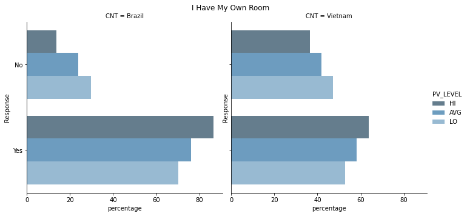

```python
multipropplot_BRVT("OWN_ROOM", cat_type7, "I Have My Own Room")
```

While a fewer Vietnamese students have their own rooms, it appears to have slightly less impact on their scores.

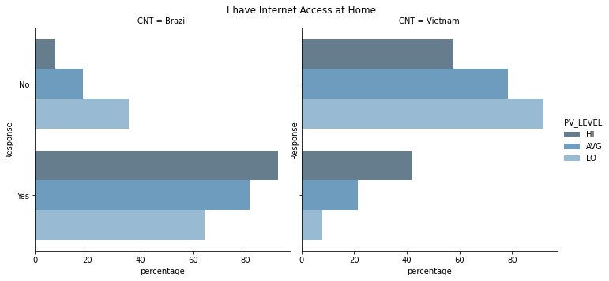

```python
multipropplot_BRVT("INTERNET", cat_type7, "I have Internet Access at Home");
```

Internet is more common among HI scoring students, but most Vietnamese students do not have access.

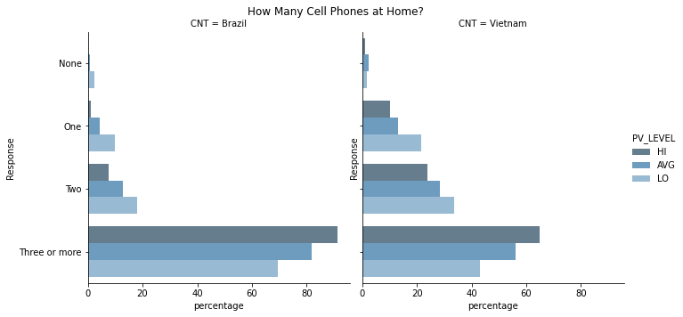

```python
multipropplot_BRVT("CELLULAR", cat_type2, "How Many Cell Phones at Home?")
```

The distribution of PV level is similar among the responses, but Vietnamese students report fewer cellular phones.

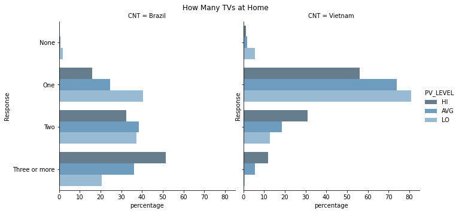

```python
multipropplot_BRVT("TV", cat_type2, "How Many TVs at Home");
```

TV ownership appears a little more significantly correlated with HI scores for the Brazilian subset. More than half HI scoring have 3+ TVs.

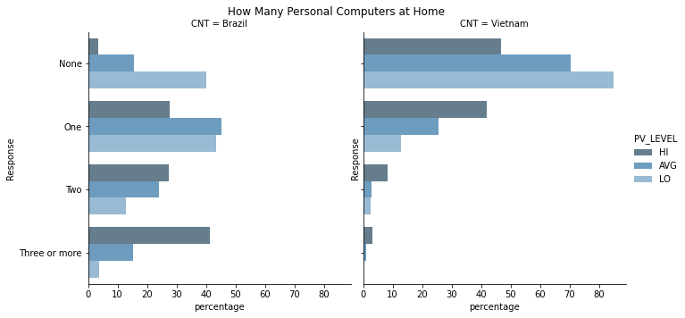

```python
multipropplot_BRVT("PC", cat_type2, "How Many Personal Computers at Home");
```

This is different from the dataset as a whole--LO scoring is significantly more skewed to fewer PCs for Brazilian students. Having several PCs is unlikely for any Vietnamese student, though a greater proportion of LO scoring students have none.

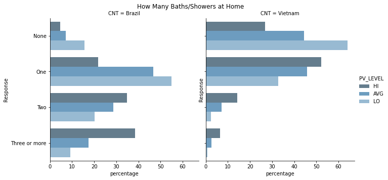

```python
multipropplot_BRVT("BATHROOM", cat_type2, "How Many Baths/Showers at Home");
```

Also different--HI scoring is skewed more toward more baths/showers for Brazilian students. However, not true for Vietnamese students; HI scoring were most likely to have just one bath/shower.

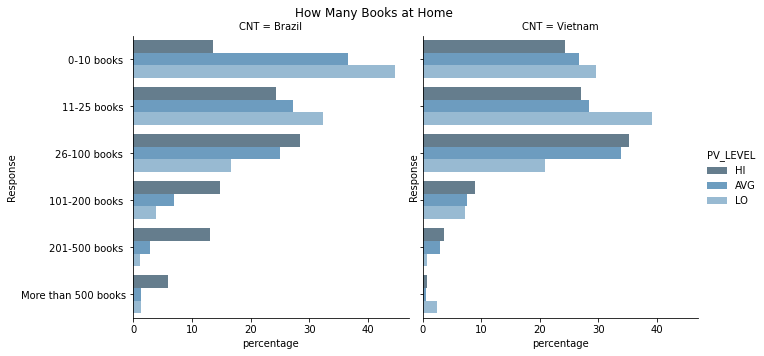

```python
multipropplot_BRVT("BOOKS", cat_type4, "How Many Books at Home");
```

Both Vietnamese and Brazilian students have fewer books in general, with 26-100 books being the threshold for the highest proportion of HI scoring students. It seems much less significant for Vietnamese students, where the proportion of LO scoring students even outpaces other groups for more than 500 books.

There isn't significantly more negative mindset in the Brazilian subset; if anything, they showed higher proportions of positive mindsets than the higher scoring Vietnamese students, but there are some interesting differences in resource access. Vietnamese students seemed to have less access to resources than Brazilians. The only measurable where the Vietnamese students clearly outpaced the Brazilians was desk ownership.

# Conclusion

Viewing the dataset as a whole, and within nations, there were key insights into the correlations between mindset, access, and math PV outcomes. My findings revealed desks, PCs, internet access, and books in the home all positively impact the distritution of PV. As do beliefs about the importance of effort, its relationship to success, perseverance, and perception of parental belief in math importance.

While we could see correlations within the nations, there were not any clear patterns uncovered to explain why Vietnamese students' PV was so much greater than Brazilian students' PV. Perhaps there is a compounding generational factor that isn't sufficiently measured by the current PISA methodology.